# R21 Capacity Assessment

### Dividing section A into larger subgroups

## Tools (performance capacity), Skills (personal capacity), Staff and Infrastructure (Workload capacity with supervisory capacity and facility capacity with support service capacity), and Structures, Systems, and Roles (Structural capacity, systems capacity, and role capacity)

```r
#performance - variables (6)/mean
########## tools
#personal - variables (6)/mean/tier group
########## skills
#workload - variables (2)/mean
#supervisory - variables (6)/mean
#facility - variables (2)/mean
#support service - variables (4)/mean
########## staff and infrastructure
#systems - variables (5)/mean
#structural - variables (4)/mean
#role - variables (3)/mean
########## structures, systems, and roles

dataRegroup20200404 <- transmute(dataclean, record_id, age, position, position2 = factor(data$position, levels = c("specialty resident","subspecialty resident","head of department","head of service","head of academic area","other"), labels = c("resident", "resident", "dept head", "dept head", "dept head", "resident")), department, department_head, residence_program, residence_year, university, gender, degree,
                        research_tools, funding, collab_support, consumables, internet, journal_access,

                        avgPerformanceCap = rowMeans(dataclean[,14:19], na.rm=TRUE),
                        avgTools = rowMeans(dataclean[,14:19], na.rm=TRUE),
                        specialty_training, knowledge, professor_experience, research_incentives, skills_training, managerial_training,

                        avgPersonalCap = rowMeans(dataclean[,20:25], na.rm=TRUE),
                        avgSkills = rowMeans(dataclean[,20:25], na.rm=TRUE),
                        workload, work_hours,

                        avgWorkloadCap = rowMeans(dataclean[,26:27], na.rm=TRUE),
                        monitoring, reporting, oversight, excel_incentives, sanctions, incentive_additional,

                        avgSupervisorCap = rowMeans(dataclean[,29:34], na.rm=TRUE),
                        infrastructure, staff_support,

                        avgFacilityCap = rowMeans(dataclean[,36:37], na.rm=TRUE),
                        consulting_firms, training_workshops, academic_institutions, public_institutions,

                        avgSupportCap = rowMeans(dataclean[,38:41], na.rm=TRUE),

                        avgStaffInfrastructure = (avgWorkloadCap+avgSupervisorCap+avgFacilityCap+avgSupportCap)/4,
                        information_flow, admin_decisions, research_exchange, travel_auth, irb_revision,

                        avgSystemsCap = rowMeans(dataclean[,44:48], na.rm=TRUE),
                        forums, research_importance, curriculum, abroad_training,
                        avgStructuralCap = rowMeans(dataclean[,50:53], na.rm=TRUE),
                        research_proposal, research_choice, research_control,

                        avgRoleCap = rowMeans(dataclean[,54:56], na.rm=TRUE),
                        avgStructuresSystems = (avgSystemsCap+avgStructuralCap+avgRoleCap)/3)
dataRegroup20200404<- cbind(dataRegroup20200404, avgTotalCap)

#calculating means of new subgroups (skills, tools, staff/infrastructure, structures/systems/roles)
mean(dataRegroup20200404$avgTotalCap, na.rm=TRUE)
```

```
## [1] 2.054772
```

```r
mean(dataRegroup20200404$avgTools, na.rm=TRUE)
```

```
## [1] 1.833114
```

```r
mean(dataRegroup20200404$avgSkills, na.rm=TRUE)
```

```
## [1] 1.957261
```

```r
mean(dataRegroup20200404$avgStaffInfrastructure, na.rm=TRUE)
```

```
## [1] 1.942905
```

```r
mean(dataRegroup20200404$avgStructuresSystems, na.rm=TRUE)
```

```
## [1] 2.301672
```

```r
print("standard deviations")
```

```
## [1] "standard deviations"
```

```r
print("total")
```

```
## [1] "total"
```

```r
sd(dataRegroup20200404$avgTotalCap, na.rm=TRUE)
```

```
## [1] 0.581478
```

```r
print("tools")
```

```
## [1] "tools"
```

```r
sd(dataRegroup20200404$avgTools, na.rm=TRUE)
```

```
## [1] 0.8328777
```

```r
print("skills")
```

```
## [1] "skills"
```

```r
sd(dataRegroup20200404$avgSkills, na.rm=TRUE)
```

```
## [1] 0.7271757
```

```r
print("infrastructure")
```

```
## [1] "infrastructure"
```

```r
sd(dataRegroup20200404$avgStaffInfrastructure, na.rm=TRUE)
```

```
## [1] 0.6665281
```

```r
print("structures")
```

```
## [1] "structures"
```

```r
sd(dataRegroup20200404$avgStructuresSystems, na.rm=TRUE)
```

```
## [1] 0.6987357
```

```r
#cronbach's alpha for new subgroups
toolsAlpha <- transmute(dataRegroup20200404, research_tools, funding, collab_support, consumables, internet, journal_access)
skillsAlpha <- transmute(dataRegroup20200404, specialty_training, knowledge, professor_experience, research_incentives, skills_training, managerial_training)
staffInfrastructureAlpha <- transmute(dataRegroup20200404, workload, work_hours, monitoring, reporting, oversight, excel_incentives, sanctions, incentive_additional,infrastructure, staff_support,consulting_firms, training_workshops, academic_institutions, public_institutions)
structuresSystemsAlpha <- transmute(dataRegroup20200404, information_flow, admin_decisions, research_exchange, travel_auth, irb_revision,forums, research_importance, curriculum, abroad_training,research_proposal, research_choice, research_control)

alpha(toolsAlpha, check.keys = TRUE)
```

```
##
## Reliability analysis
## Call: alpha(x = toolsAlpha, check.keys = TRUE)
##
##   raw_alpha std.alpha G6(smc) average_r S/N   ase mean   sd median_r
##       0.81      0.82    0.81      0.43 4.5 0.017  1.8 0.83     0.41
##
##  lower alpha upper     95% confidence boundaries
## 0.78 0.81 0.84
##
##  Reliability if an item is dropped:
##                raw_alpha std.alpha G6(smc) average_r S/N alpha se  var.r med.r
## research_tools      0.76      0.77    0.75      0.40 3.3    0.022 0.0099  0.36
## funding             0.78      0.79    0.76      0.42 3.7    0.020 0.0107  0.42
## collab_support      0.77      0.78    0.75      0.41 3.5    0.021 0.0116  0.38
## consumables         0.77      0.78    0.76      0.42 3.6    0.021 0.0137  0.36
## internet            0.79      0.80    0.78      0.45 4.0    0.019 0.0141  0.44
## journal_access      0.82      0.82    0.80      0.48 4.6    0.016 0.0101  0.49
##
##  Item statistics
##                  n raw.r std.r r.cor r.drop mean   sd
## research_tools 299  0.78  0.79  0.76   0.67  1.7 1.08
## funding        296  0.72  0.73  0.67   0.59  1.6 0.98
## collab_support 302  0.76  0.77  0.72   0.64  2.0 1.10
## consumables    301  0.75  0.75  0.69   0.61  1.8 1.21
## internet       300  0.70  0.69  0.59   0.54  1.8 1.17
## journal_access 302  0.65  0.61  0.48   0.43  2.0 1.31
##
## Non missing response frequency for each item
##                   1    2    3    4    5 miss
## research_tools 0.64 0.15 0.13 0.05 0.03 0.02
## funding        0.67 0.14 0.14 0.03 0.02 0.03
## collab_support 0.43 0.28 0.18 0.09 0.03 0.01
## consumables    0.58 0.18 0.11 0.08 0.05 0.01
## internet       0.61 0.14 0.14 0.06 0.05 0.02
## journal_access 0.53 0.16 0.16 0.08 0.08 0.01
```

```r
alpha(skillsAlpha, check.keys = TRUE)
```

```
##
## Reliability analysis
## Call: alpha(x = skillsAlpha, check.keys = TRUE)
##
##   raw_alpha std.alpha G6(smc) average_r S/N   ase mean   sd median_r
##       0.72      0.72     0.8       0.3 2.6 0.027    2 0.73    0.064
##
##  lower alpha upper     95% confidence boundaries
## 0.66 0.72 0.77
##
##  Reliability if an item is dropped:
##                      raw_alpha std.alpha G6(smc) average_r S/N alpha se var.r
## specialty_training        0.66      0.66    0.76      0.28 2.0    0.033 0.101
## knowledge                 0.62      0.62    0.70      0.25 1.6    0.037 0.079
## professor_experience      0.64      0.65    0.73      0.27 1.8    0.035 0.083
## research_incentives       0.65      0.66    0.76      0.28 1.9    0.034 0.101
## skills_training           0.75      0.75    0.77      0.38 3.0    0.023 0.088
## managerial_training       0.74      0.75    0.77      0.37 3.0    0.024 0.091
##                      med.r
## specialty_training   0.062
## knowledge            0.050
## professor_experience 0.062
## research_incentives  0.057
## skills_training      0.500
## managerial_training  0.500
##
##  Item statistics
##                        n raw.r std.r r.cor r.drop mean  sd
## specialty_training   297  0.69  0.70  0.63   0.52  2.0 1.1
## knowledge            298  0.78  0.80  0.79   0.65  1.8 1.1
## professor_experience 294  0.73  0.74  0.71   0.57  1.9 1.1
## research_incentives  285  0.70  0.72  0.64   0.54  1.9 1.1
## skills_training      299  0.50  0.46  0.35   0.23  2.2 1.2
## managerial_training  299  0.50  0.47  0.36   0.25  1.9 1.2
##
## Non missing response frequency for each item
##                         1    2    3    4    5 miss
## specialty_training   0.47 0.23 0.21 0.06 0.03 0.03
## knowledge            0.51 0.27 0.14 0.05 0.03 0.02
## professor_experience 0.48 0.29 0.13 0.07 0.04 0.04
## research_incentives  0.52 0.21 0.18 0.05 0.04 0.07
## skills_training      0.37 0.25 0.22 0.09 0.07 0.02
## managerial_training  0.51 0.22 0.17 0.05 0.05 0.02
```

```r
alpha(staffInfrastructureAlpha, check.keys = TRUE)
```

```
##
## Reliability analysis
## Call: alpha(x = staffInfrastructureAlpha, check.keys = TRUE)
##
##   raw_alpha std.alpha G6(smc) average_r S/N   ase mean   sd median_r
##       0.87      0.88     0.9      0.33   7 0.011    2 0.66     0.34
##
##  lower alpha upper     95% confidence boundaries
## 0.85 0.87 0.89
##
##  Reliability if an item is dropped:
##                       raw_alpha std.alpha G6(smc) average_r S/N alpha se var.r
## workload                   0.86      0.87    0.89      0.33 6.4    0.012 0.018
## work_hours                 0.87      0.88    0.90      0.36 7.2    0.011 0.016
## monitoring                 0.86      0.86    0.89      0.33 6.4    0.012 0.017
## reporting                  0.85      0.86    0.88      0.32 6.2    0.013 0.017
## oversight                  0.86      0.87    0.89      0.34 6.7    0.012 0.018
## excel_incentives           0.85      0.86    0.89      0.33 6.3    0.012 0.018
## sanctions                  0.88      0.88    0.90      0.36 7.3    0.010 0.015
## incentive_additional       0.86      0.87    0.89      0.34 6.6    0.012 0.018
## infrastructure             0.86      0.87    0.89      0.34 6.6    0.012 0.018
## staff_support              0.86      0.86    0.89      0.33 6.4    0.012 0.018
## consulting_firms           0.86      0.87    0.89      0.33 6.5    0.012 0.018
## training_workshops         0.86      0.87    0.89      0.33 6.5    0.012 0.017
## academic_institutions      0.85      0.86    0.88      0.33 6.4    0.012 0.016
## public_institutions        0.85      0.86    0.88      0.32 6.2    0.013 0.015
##                       med.r
## workload               0.33
## work_hours             0.35
## monitoring             0.33
## reporting              0.32
## oversight              0.34
## excel_incentives       0.33
## sanctions              0.35
## incentive_additional   0.34
## infrastructure         0.34
## staff_support          0.33
## consulting_firms       0.34
## training_workshops     0.34
## academic_institutions  0.34
```

[output cut: 20 more lines]

```
##                          1    2    3    4    5 miss
## workload              0.66 0.18 0.12 0.04 0.00 0.02
## work_hours            0.61 0.17 0.14 0.04 0.04 0.02
## monitoring            0.38 0.30 0.29 0.03 0.00 0.02
## reporting             0.34 0.32 0.23 0.08 0.03 0.03
## oversight             0.21 0.23 0.33 0.16 0.07 0.02
## excel_incentives      0.54 0.22 0.18 0.06 0.00 0.03
## sanctions             0.26 0.15 0.22 0.16 0.20 0.03
## incentive_additional  0.56 0.24 0.13 0.04 0.03 0.04
## infrastructure        0.54 0.22 0.14 0.07 0.03 0.02
## staff_support         0.58 0.22 0.13 0.07 0.01 0.02
## consulting_firms      0.40 0.27 0.21 0.08 0.04 0.03
## training_workshops    0.35 0.25 0.24 0.11 0.05 0.04
## academic_institutions 0.39 0.24 0.24 0.09 0.04 0.02
## public_institutions   0.40 0.30 0.20 0.07 0.03 0.04
```

```r
alpha(structuresSystemsAlpha, check.keys = TRUE)
```

```
##
## Reliability analysis
## Call: alpha(x = structuresSystemsAlpha, check.keys = TRUE)
##
##   raw_alpha std.alpha G6(smc) average_r S/N   ase mean   sd median_r
##       0.83      0.84    0.87      0.31 5.4 0.014  2.2 0.72     0.32
##
##  lower alpha upper     95% confidence boundaries
## 0.8 0.83 0.86
##
##  Reliability if an item is dropped:
##                     raw_alpha std.alpha G6(smc) average_r S/N alpha se var.r
## information_flow         0.82      0.83    0.85      0.31 4.9    0.016 0.019
## admin_decisions          0.82      0.83    0.85      0.30 4.8    0.016 0.018
## research_exchange        0.82      0.83    0.86      0.31 4.8    0.016 0.019
## travel_auth              0.82      0.84    0.87      0.32 5.1    0.015 0.023
## irb_revision             0.81      0.83    0.86      0.30 4.8    0.016 0.023
## forums                   0.81      0.82    0.85      0.30 4.7    0.016 0.018
## research_importance      0.82      0.83    0.85      0.31 4.9    0.016 0.020
## curriculum               0.82      0.83    0.85      0.31 4.9    0.016 0.020
## abroad_training          0.81      0.83    0.85      0.31 4.9    0.016 0.022
## research_proposal        0.83      0.84    0.86      0.33 5.4    0.015 0.019
## research_choice          0.83      0.85    0.87      0.34 5.5    0.014 0.017
## research_control         0.83      0.84    0.87      0.32 5.2    0.015 0.022
##                     med.r
## information_flow     0.32
## admin_decisions      0.32
## research_exchange    0.31
## travel_auth          0.32
## irb_revision         0.31
## forums               0.31
## research_importance  0.31
## curriculum           0.32
## abroad_training      0.32
## research_proposal    0.32
## research_choice      0.32
## research_control     0.32
##
##  Item statistics
##                       n raw.r std.r r.cor r.drop mean   sd
```

[output cut: 12 more lines]

```
##
## Non missing response frequency for each item
##                        1    2    3    4    5 miss
## information_flow    0.28 0.33 0.29 0.07 0.03 0.02
## admin_decisions     0.43 0.29 0.20 0.07 0.01 0.04
## research_exchange   0.56 0.23 0.17 0.03 0.01 0.04
## travel_auth         0.52 0.18 0.18 0.07 0.05 0.05
## irb_revision        0.38 0.19 0.30 0.10 0.03 0.03
## forums              0.58 0.20 0.16 0.04 0.01 0.03
## research_importance 0.52 0.24 0.17 0.04 0.02 0.02
## curriculum          0.44 0.20 0.23 0.09 0.04 0.02
## abroad_training     0.45 0.23 0.19 0.10 0.02 0.03
## research_proposal   0.14 0.14 0.26 0.18 0.28 0.01
## research_choice     0.18 0.19 0.24 0.18 0.21 0.02
## research_control    0.32 0.20 0.19 0.14 0.15 0.01
```

### Counting Missing

- Missing from the Potter set (Section A), excluding the Hennessy set (Section B)

```r
#dataclean9 = only the potter items, excluding open ended and hennessy and demographics
dataclean9 <- transmute(data, data$record_id, data$date,
                        data$research_tools,
                        data$funding,
                        data$collab_support,
                        data$consumables,
                        data$internet,
                        data$journal_access,
                        data$specialty_training,
                        data$knowledge,
                        data$professor_experience,
                        data$research_incentives,
                        data$skills_training,
                        data$managerial_training,
                        data$workload,
                        data$work_hours,
                        data$monitoring,
                        data$reporting,
                        data$oversight,
                        data$excel_incentives,
                        data$sanctions,
                        data$incentive_additional,
                        data$infrastructure,
                        data$staff_support,
                        data$consulting_firms,
                        data$training_workshops,
                        data$academic_institutions,
                        data$public_institutions,
                        data$information_flow,
                        data$admin_decisions,
                        data$research_exchange,
                        data$travel_auth,
                        data$irb_revision,
                        data$forums,
                        data$research_importance,
                        data$curriculum,
                        data$abroad_training,
                        data$research_proposal,
                        data$research_choice,
                        data$research_control)
dataclean9 <- dataclean9 %>% dplyr::na_if(6)
dataclean9$knowledge <- 6-data$knowledge
dataclean9$specialty_training <- 6-data$specialty_training
dataclean9$professor_experience <- 6-data$professor_experience
dataclean9$research_incentives <- 6-data$research_incentives
dataclean9 <- dataclean9 %>% dplyr::na_if(0)

table(is.na(dataclean9))
```

```
##
## FALSE  TRUE
## 13075   345
```

```r
#345 missing values from potter section (2.6%)
```

# Section A (Potter and Brough)

## Bar Graph

```r
aPerformanceCap <- mean(dataclean3$avgPerformanceCap, na.rm=TRUE)
bPersonalCap <- mean(dataclean3$avgPersonalCap, na.rm=TRUE)
cWorkloadCap <- mean(dataclean3$avgWorkloadCap, na.rm=TRUE)
dSupervisorCap <- mean(dataclean3$avgSupervisorCap, na.rm=TRUE)
eFacilityCap <- mean(dataclean3$avgFacilityCap, na.rm=TRUE)
fSupportCap <- mean(dataclean3$avgSupportCap, na.rm=TRUE)
gSystemsCap <- mean(dataclean3$avgSystemsCap, na.rm=TRUE)
hStructuralCap <- mean(dataclean3$avgStructuralCap, na.rm=TRUE)
iRoleCap <- mean(dataclean3$avgRoleCap, na.rm=TRUE)
jTotalCap <- mean(dataclean3$avgTotalCap, na.rm=TRUE)


capMeans <- data.frame(aPerformanceCap, bPersonalCap, cWorkloadCap, dSupervisorCap, eFacilityCap, fSupportCap, gSystemsCap, hStructuralCap, iRoleCap, jTotalCap)
capMeans <- data.frame(t(capMeans))

capMeans <- capMeans %>% mutate(c("aPerformanceCap", "bPersonalCap", "cWorkloadCap", "dSupervisorCap", "eFacilityCap", "fSupportCap", "gSystemsCap", "hStructuralCap", "iRoleCap", "jTotalCap"))
names(capMeans) <- c("item_average", "name")

#sorting capacity means
#capMeans <- capMeans[order(capMeans$item_average),]
capMeans <- round(capMeans$item_average, digits = 2)

class(capMeans)
```

```
## [1] "numeric"
```

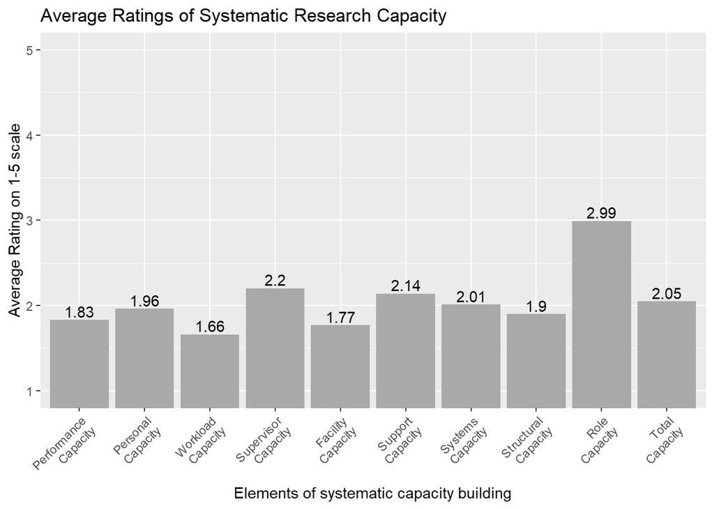

```r
capMeans <- data.frame(capMeans)

#this part is repeated because when I rounded the item_average it changed it from dataframe to numeric, but it needs to be in dataframe format. I can't only put this part after because I want to use the column names. This is not great, but it's fine for now.
capMeans <- capMeans %>% mutate(c("aPerformanceCap", "bPersonalCap", "cWorkloadCap", "dSupervisorCap", "eFacilityCap", "fSupportCap", "gSystemsCap", "hStructuralCap", "iRoleCap", "jTotalCap"))
names(capMeans) <- c("item_average", "name")



ggplot(data = capMeans, aes(x = name, y = item_average, fill = item_average)) +
  geom_bar(stat = "identity", fill = "darkgray") +
  geom_text(aes(label=item_average), position=position_dodge(width=0.9), vjust=-0.25) +
  theme(axis.text.x = element_text(angle = 45, hjust = 1), legend.position = "none") +
  scale_y_continuous("Average Rating on 1-5 scale") +
  xlab("Elements of systematic capacity building") +
  #scale_x_continuous("Elements of Systematic Capacity Building") +
  ggtitle("Average Ratings of Systematic Research Capacity") +
  coord_cartesian(ylim=c(1,5)) +
  scale_x_discrete(limits = c("aPerformanceCap", "bPersonalCap", "cWorkloadCap", "dSupervisorCap", "eFacilityCap", "fSupportCap", "gSystemsCap", "hStructuralCap", "iRoleCap", "jTotalCap"),
                   labels = c("Performance\nCapacity", "Personal\nCapacity", "Workload\nCapacity", "Supervisor\nCapacity", "Facility\nCapacity", "Support\nCapacity", "Systems\nCapacity", "Structural\nCapacity","Role\nCapacity", "Total\nCapacity"))
```

## Averages by position and Department - Section A

```r
#Differences by position
avgResident1 <- filter(dataclean3, position2=="resident")
avgHead1 <- filter(dataclean3, position2=="dept head")
print("total, total, resident, head")
```

```
## [1] "total, total, resident, head"
```

```r
summary(aov(dataclean3$avgTotalCap ~ dataclean3$position2))
```

```
##                       Df Sum Sq Mean Sq F value Pr(>F)
## dataclean3$position2   1   1.74  1.7369   5.191 0.0234 *
## Residuals            302 101.04  0.3346
## ---
## Signif. codes:  0 '***' 0.001 '**' 0.01 '*' 0.05 '.' 0.1 ' ' 1
## 1 observation deleted due to missingness
```

```r
table(dataclean3$position2)
```

```
##
##  resident dept head
##       230        74
```

```r
mean(dataclean3$avgTotalCap, na.rm=TRUE)
```

```
## [1] 2.054772
```

```r
mean(avgResident1$avgTotalCap, na.rm=TRUE)
```

```
## [1] 2.012256
```

```r
mean(avgHead1$avgTotalCap, na.rm=TRUE)
```

```
## [1] 2.188388
```

```r
print("sd resident")
```

```
## [1] "sd resident"
```

```r
sd(avgResident1$avgTotalCap, na.rm=TRUE)
```

```
## [1] 0.590083
```

```r
print("sd head")
```

```
## [1] "sd head"
```

```r
sd(avgHead1$avgTotalCap, na.rm=TRUE)
```

```
## [1] 0.5401854
```

```r
#Differences by Gender
avgFemale1 <- filter(dataclean3, gender=="female")
avgMale1 <- filter(dataclean3, gender=="male")
print("gender")
```

```
## [1] "gender"
```

```r
print("total, total, female, male")
```

```
## [1] "total, total, female, male"
```

```r
summary(aov(dataclean3$avgTotalCap ~ dataclean3$gender))
```

```
##                    Df Sum Sq Mean Sq F value Pr(>F)
## dataclean3$gender   1   0.86  0.8627   2.565   0.11
## Residuals         303 101.92  0.3364
```

```r
table(dataclean3$gender)
```

```
##
##   male female
##    150    155
```

```r
mean(dataclean3$avgTotalCap, na.rm=TRUE)
```

```
## [1] 2.054772
```

```r
print("mean female")
```

```
## [1] "mean female"
```

```r
mean(avgFemale1$avgTotalCap, na.rm=TRUE)
```

```
## [1] 2.002454
```

```r
print("mean male")
```

```
## [1] "mean male"
```

```r
mean(avgMale1$avgTotalCap, na.rm=TRUE)
```

```
## [1] 2.108834
```

```r
print("sd female")
```

```
## [1] "sd female"
```

```r
sd(avgFemale1$avgTotalCap, na.rm=TRUE)
```

```
## [1] 0.6006142
```

```r
print("sd male")
```

```
## [1] "sd male"
```

```r
sd(avgMale1$avgTotalCap, na.rm=TRUE)
```

```
## [1] 0.5578677
```

```r
#Differences by Degree
avgUniversity <- filter(dataclean3, degree=="1. university")
avgMasters <- filter(dataclean3, degree=="2. masters or med specialty")
avgMasters2 <- filter(dataclean3, degree=="3. 2nd masters or med subspecialty")
print("degree")
```

```
## [1] "degree"
```

```r
print("total, university, master, master2")
```

```
## [1] "total, university, master, master2"
```

```r
summary(aov(dataclean3$avgTotalCap ~ dataclean3$degree))
```

```
##                    Df Sum Sq Mean Sq F value Pr(>F)
## dataclean3$degree   2   1.28  0.6410   1.907   0.15
## Residuals         302 101.51  0.3361
```

```r
table(dataclean3$degree)
```

```
##
##                      1. university        2. masters or med specialty
##                                172                                109
## 3. 2nd masters or med subspecialty
##                                 24
```

```r
mean(dataclean3$avgTotalCap, na.rm=TRUE)
```

```
## [1] 2.054772
```

```r
mean(avgUniversity$avgTotalCap, na.rm=TRUE)
```

```
## [1] 2.000199
```

```r
mean(avgMasters$avgTotalCap, na.rm=TRUE)
```

```
## [1] 2.138672
```

```r
mean(avgMasters2$avgTotalCap, na.rm=TRUE)
```

```
## [1] 2.064839
```

```r
print("sd university")
```

```
## [1] "sd university"
```

```r
sd(avgUniversity$avgTotalCap, na.rm=TRUE)
```

```
## [1] 0.5826097
```

```r
print("sd masters")
```

```
## [1] "sd masters"
```

```r
sd(avgMasters$avgTotalCap, na.rm=TRUE)
```

```
## [1] 0.571302
```

```r
print("sd 2nd masters")
```

```
## [1] "sd 2nd masters"
```

```r
sd(avgMasters2$avgTotalCap, na.rm=TRUE)
```

```
## [1] 0.597553
```

```r
#Differences by Department
avgAnesthesia <- filter(dataclean3, department=="anesthesia")
avgPediatrics <- filter(dataclean3, department=="pediatrics")
avgSurgery <- filter(dataclean3, department=="general surgery")
avgInternal <- filter(dataclean3, department=="internal medicine")
avgTrauma <- filter(dataclean3, department=="trauma")
avgObgyn <- filter(dataclean3, department=="obgyn")
avgRadiology <- filter(dataclean3, department=="radiology")
avgPathology <- filter(dataclean3, department=="pathology")
#Grouping the three departments with <10 into one
avgOther <- filter(dataclean3, department=="other")

table(dataclean3$department)
```

```
##
##        anesthesia   general surgery internal medicine             obgyn
##                33                34                64                60
##             other         pathology        pediatrics         radiology
##                 9                15                40                17
##            trauma
##                30
```

```r
print("total department")
```

```
## [1] "total department"
```

```r
summary(aov(dataclean3$avgTotalCap ~ dataclean3$department))
```

```
##                        Df Sum Sq Mean Sq F value   Pr(>F)
## dataclean3$department   8  20.68  2.5856    9.24 2.35e-11 ***
## Residuals             293  81.98  0.2798
## ---
## Signif. codes:  0 '***' 0.001 '**' 0.01 '*' 0.05 '.' 0.1 ' ' 1
## 3 observations deleted due to missingness
```

```r
print("total")
```

```
## [1] "total"
```

```r
mean(dataclean3$avgTotalCap, na.rm=TRUE)
```

```
## [1] 2.054772
```

```r
sd(dataclean3$avgTotalCap, na.rm=TRUE)
```

```
## [1] 0.581478
```

```r
print("other")
```

```
## [1] "other"
```

```r
mean(avgOther$avgTotalCap, na.rm=TRUE)
```

```
## [1] 2.540167
```

```r
sd(avgOther$avgTotalCap, na.rm=TRUE)
```

```
## [1] 0.7320835
```

```r
print("anesthesia")
```

```
## [1] "anesthesia"
```

```r
mean(avgAnesthesia$avgTotalCap, na.rm=TRUE)
```

```
## [1] 2.303833
```

```r
sd(avgAnesthesia$avgTotalCap, na.rm=TRUE)
```

```
## [1] 0.6803192
```

```r
print("surgery")
```

```
## [1] "surgery"
```

```r
mean(avgSurgery$avgTotalCap, na.rm=TRUE)
```

```
## [1] 2.254195
```

```r
sd(avgSurgery$avgTotalCap, na.rm=TRUE)
```

```
## [1] 0.5564277
```

```r
print("internal")
```

```
## [1] "internal"
```

```r
mean(avgInternal$avgTotalCap, na.rm=TRUE)
```

```
## [1] 2.239949
```

```r
sd(avgInternal$avgTotalCap, na.rm=TRUE)
```

```
## [1] 0.5409542
```

```r
print("radiology")
```

```
## [1] "radiology"
```

```r
mean(avgRadiology$avgTotalCap, na.rm=TRUE)
```

```
## [1] 2.239231
```

```r
sd(avgRadiology$avgTotalCap, na.rm=TRUE)
```

```
## [1] 0.6870278
```

```r
print("Trauma")
```

```
## [1] "Trauma"
```

```r
mean(avgTrauma$avgTotalCap, na.rm=TRUE)
```

```
## [1] 2.100341
```

```r
sd(avgTrauma$avgTotalCap, na.rm=TRUE)
```

```
## [1] 0.4981676
```

```r
print("pathology")
```

```
## [1] "pathology"
```

```r
mean(avgPathology$avgTotalCap, na.rm=TRUE)
```

```
## [1] 1.916493
```

```r
sd(avgPathology$avgTotalCap, na.rm=TRUE)
```

```
## [1] 0.4922666
```

```r
print("pediatric")
```

```
## [1] "pediatric"
```

```r
mean(avgPediatrics$avgTotalCap, na.rm=TRUE)
```

```
## [1] 1.841654
```

```r
sd(avgPediatrics$avgTotalCap, na.rm=TRUE)
```

```
## [1] 0.4628145
```

```r
print("obgyn")
```

```
## [1] "obgyn"
```

```r
mean(avgObgyn$avgTotalCap, na.rm=TRUE)
```

```
## [1] 1.641928
```

```r
sd(avgObgyn$avgTotalCap, na.rm=TRUE)
```

```
## [1] 0.3621384
```

```r
#Post hoc test to compare internal medicine (n=64) to other departments

pairwise.t.test(dataclean3$avgTotalCap, dataclean3$department, p.adj = "none")
```

```
##
##  Pairwise comparisons using t tests with pooled SD
##
## data:  dataclean3$avgTotalCap and dataclean3$department
##
##                   anesthesia general surgery internal medicine obgyn   other
## general surgery   0.70125    -               -                 -       -
## internal medicine 0.57350    0.89911         -                 -       -
## obgyn             2.0e-08    1.4e-07         1.1e-09           -       -
## other             0.23576    0.15032         0.11196           3.2e-06 -
## pathology         0.01936    0.04032         0.03387           0.07320 0.00551
## pediatrics        0.00024    0.00094         0.00022           0.06536 0.00040
## radiology         0.68278    0.92420         0.99604           5.1e-05 0.16862
## trauma            0.12834    0.24653         0.23392           0.00013 0.02948
##                   pathology pediatrics radiology
## general surgery   -         -          -
## internal medicine -         -          -
## obgyn             -         -          -
## other             -         -          -
## pathology         -         -          -
## pediatrics        0.64064   -          -
## radiology         0.08607   0.00991    -
## trauma            0.27264   0.04379    0.38779
##
## P value adjustment method: none
```

```r
pairwise.t.test(dataclean3$avgTotalCap, dataclean3$department, p.adj = "bonf")
```

```
##
##  Pairwise comparisons using t tests with pooled SD
##
## data:  dataclean3$avgTotalCap and dataclean3$department
##
##                   anesthesia general surgery internal medicine obgyn   other
## general surgery   1.00000    -               -                 -       -
## internal medicine 1.00000    1.00000         -                 -       -
## obgyn             7.1e-07    5.2e-06         4.1e-08           -       -
## other             1.00000    1.00000         1.00000           0.00011 -
## pathology         0.69698    1.00000         1.00000           1.00000 0.19838
## pediatrics        0.00875    0.03367         0.00810           1.00000 0.01451
## radiology         1.00000    1.00000         1.00000           0.00185 1.00000
## trauma            1.00000    1.00000         1.00000           0.00473 1.00000
##                   pathology pediatrics radiology
## general surgery   -         -          -
## internal medicine -         -          -
## obgyn             -         -          -
## other             -         -          -
## pathology         -         -          -
## pediatrics        1.00000   -          -
## radiology         1.00000   0.35664    -
## trauma            1.00000   1.00000    1.00000
##
## P value adjustment method: bonferroni
```

```r
table(dataclean3$department)
```

```
##
##        anesthesia   general surgery internal medicine             obgyn
##                33                34                64                60
##             other         pathology        pediatrics         radiology
##                 9                15                40                17
##            trauma
##                30
```

## Cronbach’s Alpha

> Cronbach’s alpha for the entire section is 0.92 (95CI = .91,.93).

```r
performanceAlpha <- transmute(dataclean, research_tools, funding, collab_support, consumables, internet, journal_access)
alpha(performanceAlpha)
```

```
##
## Reliability analysis
## Call: alpha(x = performanceAlpha)
##
##   raw_alpha std.alpha G6(smc) average_r S/N   ase mean   sd median_r
##       0.81      0.82    0.81      0.43 4.5 0.017  1.8 0.83     0.41
##
##  lower alpha upper     95% confidence boundaries
## 0.78 0.81 0.84
##
##  Reliability if an item is dropped:
##                raw_alpha std.alpha G6(smc) average_r S/N alpha se  var.r med.r
## research_tools      0.76      0.77    0.75      0.40 3.3    0.022 0.0099  0.36
## funding             0.78      0.79    0.76      0.42 3.7    0.020 0.0107  0.42
## collab_support      0.77      0.78    0.75      0.41 3.5    0.021 0.0116  0.38
## consumables         0.77      0.78    0.76      0.42 3.6    0.021 0.0137  0.36
## internet            0.79      0.80    0.78      0.45 4.0    0.019 0.0141  0.44
## journal_access      0.82      0.82    0.80      0.48 4.6    0.016 0.0101  0.49
##
##  Item statistics
##                  n raw.r std.r r.cor r.drop mean   sd
## research_tools 299  0.78  0.79  0.76   0.67  1.7 1.08
## funding        296  0.72  0.73  0.67   0.59  1.6 0.98
## collab_support 302  0.76  0.77  0.72   0.64  2.0 1.10
## consumables    301  0.75  0.75  0.69   0.61  1.8 1.21
## internet       300  0.70  0.69  0.59   0.54  1.8 1.17
## journal_access 302  0.65  0.61  0.48   0.43  2.0 1.31
##
## Non missing response frequency for each item
##                   1    2    3    4    5 miss
## research_tools 0.64 0.15 0.13 0.05 0.03 0.02
## funding        0.67 0.14 0.14 0.03 0.02 0.03
## collab_support 0.43 0.28 0.18 0.09 0.03 0.01
## consumables    0.58 0.18 0.11 0.08 0.05 0.01
## internet       0.61 0.14 0.14 0.06 0.05 0.02
## journal_access 0.53 0.16 0.16 0.08 0.08 0.01
```

```r
personalApha <- transmute(dataclean, specialty_training, knowledge, professor_experience, research_incentives, skills_training, managerial_training)
alpha(personalApha, check.keys=TRUE)
```

```
##
## Reliability analysis
## Call: alpha(x = personalApha, check.keys = TRUE)
##
##   raw_alpha std.alpha G6(smc) average_r S/N   ase mean   sd median_r
##       0.72      0.72     0.8       0.3 2.6 0.027    2 0.73    0.064
##
##  lower alpha upper     95% confidence boundaries
## 0.66 0.72 0.77
##
##  Reliability if an item is dropped:
##                      raw_alpha std.alpha G6(smc) average_r S/N alpha se var.r
## specialty_training        0.66      0.66    0.76      0.28 2.0    0.033 0.101
## knowledge                 0.62      0.62    0.70      0.25 1.6    0.037 0.079
## professor_experience      0.64      0.65    0.73      0.27 1.8    0.035 0.083
## research_incentives       0.65      0.66    0.76      0.28 1.9    0.034 0.101
## skills_training           0.75      0.75    0.77      0.38 3.0    0.023 0.088
## managerial_training       0.74      0.75    0.77      0.37 3.0    0.024 0.091
##                      med.r
## specialty_training   0.062
## knowledge            0.050
## professor_experience 0.062
## research_incentives  0.057
## skills_training      0.500
## managerial_training  0.500
##
##  Item statistics
##                        n raw.r std.r r.cor r.drop mean  sd
## specialty_training   297  0.69  0.70  0.63   0.52  2.0 1.1
## knowledge            298  0.78  0.80  0.79   0.65  1.8 1.1
## professor_experience 294  0.73  0.74  0.71   0.57  1.9 1.1
## research_incentives  285  0.70  0.72  0.64   0.54  1.9 1.1
## skills_training      299  0.50  0.46  0.35   0.23  2.2 1.2
## managerial_training  299  0.50  0.47  0.36   0.25  1.9 1.2
##
## Non missing response frequency for each item
##                         1    2    3    4    5 miss
## specialty_training   0.47 0.23 0.21 0.06 0.03 0.03
## knowledge            0.51 0.27 0.14 0.05 0.03 0.02
## professor_experience 0.48 0.29 0.13 0.07 0.04 0.04
## research_incentives  0.52 0.21 0.18 0.05 0.04 0.07
## skills_training      0.37 0.25 0.22 0.09 0.07 0.02
## managerial_training  0.51 0.22 0.17 0.05 0.05 0.02
```

```r
#for personal capacity, items were reversed coded manually in the dataframe dataclean. Check.keys was left on here, but it did a better job when i did it manually than when i let it detect and code.

workloadApha <- transmute(dataclean, workload, work_hours)
alpha(workloadApha, check.keys=TRUE)
```

```
##
## Reliability analysis
## Call: alpha(x = workloadApha, check.keys = TRUE)
##
##   raw_alpha std.alpha G6(smc) average_r S/N   ase mean   sd median_r
##       0.53      0.54    0.37      0.37 1.2 0.053  1.7 0.87     0.37
##
##  lower alpha upper     95% confidence boundaries
## 0.42 0.53 0.63
##
##  Reliability if an item is dropped:
##            raw_alpha std.alpha G6(smc) average_r S/N alpha se var.r med.r
## workload        0.37      0.37    0.13      0.37  NA       NA  0.37  0.37
## work_hours      0.13      0.37      NA        NA  NA       NA  0.13  0.37
##
##  Item statistics
##              n raw.r std.r r.cor r.drop mean   sd
## workload   299  0.80  0.83   0.5   0.37  1.6 0.88
## work_hours 298  0.88  0.83   0.5   0.37  1.7 1.10
##
## Non missing response frequency for each item
##               1    2    3    4    5 miss
## workload   0.66 0.18 0.12 0.04 0.00 0.02
## work_hours 0.61 0.17 0.14 0.04 0.04 0.02
```

```r
supervisorAlpha <- transmute(dataclean, monitoring, reporting, oversight, excel_incentives, sanctions, incentive_additional)
alpha(supervisorAlpha, check.keys = TRUE)
```

```
##
## Reliability analysis
## Call: alpha(x = supervisorAlpha, check.keys = TRUE)
##
##   raw_alpha std.alpha G6(smc) average_r S/N  ase mean   sd median_r
##       0.78       0.8    0.81       0.4 3.9 0.02  2.2 0.77     0.37
##
##  lower alpha upper     95% confidence boundaries
## 0.74 0.78 0.82
##
##  Reliability if an item is dropped:
##                      raw_alpha std.alpha G6(smc) average_r S/N alpha se var.r
## monitoring                0.74      0.76    0.75      0.39 3.2    0.024 0.019
## reporting                 0.71      0.74    0.72      0.36 2.8    0.026 0.016
## oversight                 0.73      0.76    0.77      0.39 3.2    0.025 0.030
## excel_incentives          0.73      0.75    0.74      0.37 3.0    0.025 0.023
## sanctions                 0.81      0.81    0.81      0.47 4.4    0.017 0.016
## incentive_additional      0.74      0.77    0.76      0.40 3.3    0.024 0.023
##                      med.r
## monitoring            0.36
## reporting             0.35
## oversight             0.36
## excel_incentives      0.35
## sanctions             0.43
## incentive_additional  0.39
##
##  Item statistics
##                        n raw.r std.r r.cor r.drop mean   sd
## monitoring           300  0.68  0.72  0.67   0.56  2.0 0.91
## reporting            297  0.77  0.80  0.78   0.65  2.1 1.06
## oversight            299  0.74  0.72  0.64   0.57  2.6 1.17
## excel_incentives     295  0.73  0.76  0.71   0.61  1.8 0.97
## sanctions            295  0.61  0.54  0.38   0.34  2.9 1.48
## incentive_additional 293  0.68  0.70  0.63   0.52  1.7 1.04
##
## Non missing response frequency for each item
##                         1    2    3    4    5 miss
## monitoring           0.38 0.30 0.29 0.03 0.00 0.02
## reporting            0.34 0.32 0.23 0.08 0.03 0.03
## oversight            0.21 0.23 0.33 0.16 0.07 0.02
## excel_incentives     0.54 0.22 0.18 0.06 0.00 0.03
## sanctions            0.26 0.15 0.22 0.16 0.20 0.03
## incentive_additional 0.56 0.24 0.13 0.04 0.03 0.04
```

```r
facilityAlpha <- transmute(dataclean, infrastructure, staff_support)
alpha(facilityAlpha, check.keys = TRUE)
```

```
##
## Reliability analysis
## Call: alpha(x = facilityAlpha, check.keys = TRUE)
##
##   raw_alpha std.alpha G6(smc) average_r S/N   ase mean   sd median_r
##       0.76      0.76    0.62      0.62 3.2 0.027  1.8 0.93     0.62
##
##  lower alpha upper     95% confidence boundaries
## 0.71 0.76 0.81
##
##  Reliability if an item is dropped:
##                raw_alpha std.alpha G6(smc) average_r S/N alpha se var.r med.r
## infrastructure      0.62      0.62    0.38      0.62  NA       NA  0.62  0.62
## staff_support       0.38      0.62      NA        NA  NA       NA  0.38  0.62
##
##  Item statistics
##                  n raw.r std.r r.cor r.drop mean   sd
## infrastructure 299  0.91   0.9  0.71   0.62  1.8 1.09
## staff_support  300  0.89   0.9  0.71   0.62  1.7 0.98
##
## Non missing response frequency for each item
##                   1    2    3    4    5 miss
## infrastructure 0.54 0.22 0.14 0.07 0.03 0.02
## staff_support  0.58 0.22 0.13 0.07 0.01 0.02
```

```r
supportAlpha <- transmute(dataclean, consulting_firms, training_workshops, academic_institutions, public_institutions)
alpha(supportAlpha, check.keys = TRUE)
```

```
##
## Reliability analysis
## Call: alpha(x = supportAlpha, check.keys = TRUE)
##
##   raw_alpha std.alpha G6(smc) average_r S/N   ase mean   sd median_r
##       0.83      0.84    0.82      0.56 5.1 0.016  2.1 0.93     0.53
##
##  lower alpha upper     95% confidence boundaries
## 0.8 0.83 0.86
##
##  Reliability if an item is dropped:
##                       raw_alpha std.alpha G6(smc) average_r S/N alpha se
## consulting_firms           0.83      0.84    0.80      0.63 5.1    0.017
## training_workshops         0.81      0.81    0.78      0.58 4.2    0.020
## academic_institutions      0.76      0.76    0.68      0.52 3.2    0.023
## public_institutions        0.75      0.75    0.67      0.50 3.0    0.025
##                         var.r med.r
## consulting_firms      0.01792  0.56
## training_workshops    0.03128  0.52
## academic_institutions 0.00065  0.52
## public_institutions   0.00302  0.50
##
##  Item statistics
##                         n raw.r std.r r.cor r.drop mean  sd
## consulting_firms      297  0.75  0.75  0.61   0.56  2.1 1.1
## training_workshops    293  0.80  0.80  0.68   0.63  2.3 1.2
## academic_institutions 299  0.85  0.85  0.82   0.72  2.1 1.1
## public_institutions   294  0.86  0.87  0.85   0.75  2.0 1.1
##
## Non missing response frequency for each item
##                          1    2    3    4    5 miss
## consulting_firms      0.40 0.27 0.21 0.08 0.04 0.03
## training_workshops    0.35 0.25 0.24 0.11 0.05 0.04
## academic_institutions 0.39 0.24 0.24 0.09 0.04 0.02
## public_institutions   0.40 0.30 0.20 0.07 0.03 0.04
```

```r
systemsAlpha <- transmute(dataclean, information_flow, admin_decisions, research_exchange, travel_auth, irb_revision)
alpha(systemsAlpha, check.keys = TRUE)
```

```
##
## Reliability analysis
## Call: alpha(x = systemsAlpha, check.keys = TRUE)
##
##   raw_alpha std.alpha G6(smc) average_r S/N   ase mean   sd median_r
##       0.77      0.78    0.77      0.42 3.6 0.021    2 0.78     0.41
##
##  lower alpha upper     95% confidence boundaries
## 0.73 0.77 0.81
##
##  Reliability if an item is dropped:
##                   raw_alpha std.alpha G6(smc) average_r S/N alpha se  var.r
## information_flow       0.71      0.72    0.67      0.39 2.6    0.027 0.0055
## admin_decisions        0.70      0.71    0.66      0.38 2.5    0.028 0.0101
## research_exchange      0.72      0.73    0.71      0.40 2.7    0.027 0.0234
## travel_auth            0.79      0.80    0.76      0.49 3.9    0.020 0.0092
## irb_revision           0.74      0.75    0.72      0.43 3.0    0.025 0.0239
##                   med.r
## information_flow   0.36
## admin_decisions    0.39
## research_exchange  0.36
## travel_auth        0.48
## irb_revision       0.41
##
##  Item statistics
##                     n raw.r std.r r.cor r.drop mean   sd
## information_flow  299  0.77  0.78  0.74   0.61  2.2 1.04
## admin_decisions   294  0.78  0.79  0.75   0.64  1.9 1.00
## research_exchange 293  0.74  0.76  0.67   0.59  1.7 0.93
## travel_auth       290  0.64  0.61  0.44   0.39  2.0 1.20
## irb_revision      295  0.74  0.72  0.61   0.54  2.2 1.13
##
## Non missing response frequency for each item
##                      1    2    3    4    5 miss
## information_flow  0.28 0.33 0.29 0.07 0.03 0.02
## admin_decisions   0.43 0.29 0.20 0.07 0.01 0.04
## research_exchange 0.56 0.23 0.17 0.03 0.01 0.04
## travel_auth       0.52 0.18 0.18 0.07 0.05 0.05
## irb_revision      0.38 0.19 0.30 0.10 0.03 0.03
```

```r
structuralAlpha <- transmute(dataclean, forums, research_importance, curriculum, abroad_training)
alpha(structuralAlpha, check.keys = TRUE)
```

```
##
## Reliability analysis
## Call: alpha(x = structuralAlpha, check.keys = TRUE)
##
##   raw_alpha std.alpha G6(smc) average_r S/N   ase mean   sd median_r
##       0.79      0.79    0.76      0.49 3.8 0.019  1.9 0.84      0.5
##
##  lower alpha upper     95% confidence boundaries
## 0.75 0.79 0.83
##
##  Reliability if an item is dropped:
##                     raw_alpha std.alpha G6(smc) average_r S/N alpha se  var.r
## forums                   0.75      0.75    0.69      0.50 3.0    0.024 0.0160
## research_importance      0.74      0.74    0.67      0.49 2.9    0.025 0.0073
## curriculum               0.70      0.70    0.62      0.44 2.4    0.030 0.0085
## abroad_training          0.76      0.76    0.69      0.52 3.2    0.024 0.0033
##                     med.r
## forums               0.56
## research_importance  0.45
## curriculum           0.43
## abroad_training      0.54
##
##  Item statistics
##                       n raw.r std.r r.cor r.drop mean   sd
## forums              295  0.75  0.77  0.65   0.58  1.7 0.94
## research_importance 299  0.78  0.78  0.68   0.59  1.8 1.01
## curriculum          300  0.85  0.83  0.76   0.68  2.1 1.17
## abroad_training     296  0.77  0.76  0.64   0.57  2.0 1.11
##
## Non missing response frequency for each item
##                        1    2    3    4    5 miss
## forums              0.58 0.20 0.16 0.04 0.01 0.03
## research_importance 0.52 0.24 0.17 0.04 0.02 0.02
## curriculum          0.44 0.20 0.23 0.09 0.04 0.02
## abroad_training     0.45 0.23 0.19 0.10 0.02 0.03
```

```r
roleAlpha <- transmute(dataclean, research_proposal, research_choice, research_control)
alpha(roleAlpha, check.keys = TRUE)
```

```
##
## Reliability analysis
## Call: alpha(x = roleAlpha, check.keys = TRUE)
##
##   raw_alpha std.alpha G6(smc) average_r S/N   ase mean  sd median_r
##       0.69      0.69    0.61      0.43 2.2 0.031    3 1.1     0.37
##
##  lower alpha upper     95% confidence boundaries
## 0.63 0.69 0.75
##
##  Reliability if an item is dropped:
##                   raw_alpha std.alpha G6(smc) average_r S/N alpha se var.r
## research_proposal      0.54      0.54    0.37      0.37 1.2    0.053    NA
## research_choice        0.54      0.54    0.37      0.37 1.2    0.053    NA
## research_control       0.70      0.70    0.54      0.54 2.4    0.034    NA
##                   med.r
## research_proposal  0.37
## research_choice    0.37
## research_control   0.54
##
##  Item statistics
##                     n raw.r std.r r.cor r.drop mean  sd
## research_proposal 301  0.81  0.81  0.67   0.55  3.3 1.4
## research_choice   299  0.81  0.81  0.67   0.55  3.1 1.4
## research_control  301  0.74  0.74  0.50   0.42  2.6 1.4
##
## Non missing response frequency for each item
##                      1    2    3    4    5 miss
## research_proposal 0.14 0.14 0.26 0.18 0.28 0.01
## research_choice   0.18 0.19 0.24 0.18 0.21 0.02
## research_control  0.32 0.20 0.19 0.14 0.15 0.01
```

```r
totalAlpha <- transmute(dataclean, research_tools, funding, collab_support, consumables, internet, journal_access, specialty_training, knowledge, professor_experience, research_incentives, skills_training, managerial_training, workload, work_hours, monitoring, reporting, oversight, excel_incentives, sanctions, incentive_additional, infrastructure, staff_support, consulting_firms, training_workshops, academic_institutions, public_institutions, information_flow, admin_decisions, research_exchange, travel_auth, irb_revision, forums, research_importance, curriculum, abroad_training, research_proposal, research_choice, research_control)

alpha(totalAlpha, check.keys = TRUE)
```

```
##
## Reliability analysis
## Call: alpha(x = totalAlpha, check.keys = TRUE)
##
##   raw_alpha std.alpha G6(smc) average_r S/N    ase mean   sd median_r
##       0.92      0.93    0.95      0.25  13 0.0064  2.1 0.58     0.25
##
##  lower alpha upper     95% confidence boundaries
## 0.91 0.92 0.93
##
##  Reliability if an item is dropped:
##                       raw_alpha std.alpha G6(smc) average_r S/N alpha se var.r
## research_tools             0.92      0.93    0.95      0.25  12   0.0067 0.018
## funding                    0.92      0.92    0.95      0.25  12   0.0067 0.018
## collab_support             0.92      0.92    0.95      0.25  12   0.0067 0.018
## consumables                0.92      0.93    0.95      0.25  12   0.0066 0.018
## internet                   0.92      0.93    0.95      0.25  13   0.0065 0.019
## journal_access             0.92      0.93    0.95      0.25  12   0.0066 0.019
## specialty_training         0.92      0.93    0.95      0.26  13   0.0064 0.017
## knowledge                  0.92      0.93    0.95      0.25  13   0.0065 0.018
## professor_experience       0.92      0.93    0.95      0.26  13   0.0065 0.018
## research_incentives        0.92      0.93    0.95      0.25  13   0.0065 0.018
## skills_training            0.92      0.93    0.95      0.25  13   0.0065 0.018
## managerial_training        0.92      0.93    0.95      0.25  13   0.0065 0.018
## workload                   0.92      0.92    0.95      0.25  12   0.0067 0.018
## work_hours                 0.92      0.93    0.95      0.26  13   0.0065 0.019
## monitoring                 0.92      0.92    0.95      0.25  12   0.0067 0.018
## reporting                  0.92      0.92    0.95      0.25  12   0.0068 0.018
## oversight                  0.92      0.93    0.95      0.25  12   0.0066 0.019
## excel_incentives           0.92      0.92    0.95      0.25  12   0.0067 0.018
## sanctions                  0.92      0.93    0.95      0.26  13   0.0063 0.018
## incentive_additional       0.92      0.92    0.95      0.25  12   0.0067 0.019
## infrastructure             0.92      0.93    0.95      0.25  12   0.0066 0.019
## staff_support              0.92      0.92    0.95      0.25  12   0.0067 0.018
## consulting_firms           0.92      0.93    0.95      0.25  12   0.0066 0.018
## training_workshops         0.92      0.93    0.95      0.25  12   0.0067 0.018
## academic_institutions      0.92      0.92    0.95      0.25  12   0.0067 0.018
## public_institutions        0.92      0.92    0.95      0.25  12   0.0067 0.018
## information_flow           0.92      0.92    0.95      0.25  12   0.0067 0.018
## admin_decisions            0.92      0.92    0.95      0.25  12   0.0067 0.018
```

[output cut: 116 more lines]

```
## training_workshops    0.35 0.25 0.24 0.11 0.05 0.04
## academic_institutions 0.39 0.24 0.24 0.09 0.04 0.02
## public_institutions   0.40 0.30 0.20 0.07 0.03 0.04
## information_flow      0.28 0.33 0.29 0.07 0.03 0.02
## admin_decisions       0.43 0.29 0.20 0.07 0.01 0.04
## research_exchange     0.56 0.23 0.17 0.03 0.01 0.04
## travel_auth           0.52 0.18 0.18 0.07 0.05 0.05
## irb_revision          0.38 0.19 0.30 0.10 0.03 0.03
## forums                0.58 0.20 0.16 0.04 0.01 0.03
## research_importance   0.52 0.24 0.17 0.04 0.02 0.02
## curriculum            0.44 0.20 0.23 0.09 0.04 0.02
## abroad_training       0.45 0.23 0.19 0.10 0.02 0.03
## research_proposal     0.14 0.14 0.26 0.18 0.28 0.01
## research_choice       0.18 0.19 0.24 0.18 0.21 0.02
## research_control      0.32 0.20 0.19 0.14 0.15 0.01
```

# Section B (Henessy-Hicks)

```r
#first making a new dataframe with just demographics and the hennessy data, separate from potter data because if different cleaning methods (e.g., 6 = na in potter but not in hennessy)
#also making new columns for averages
#grouped "other position" with "resident" in position2 because there are only 7 so too few for analysis as group and there was mixed education level and age
clean4 <- transmute(data, record_id, age, position, position2 = factor(data$position, levels = c("specialty resident","subspecialty resident","head of department","head of service","head of academic area","other"), labels = c("resident", "resident", "dept head", "dept head", "dept head", "resident")), department_head, residence_program, department, residence_year, university, gender, degree, evaluating, topics, design, information_collection, new_ideas,
                    avgResearchDesign = ((evaluating + topics + design + information_collection + new_ideas)/5), paperwork, resource_access, time_management, admin_activitives,
                    avgResearchManagement = ((paperwork + resource_access + time_management + admin_activitives)/4), instructing, feedback, team_member, colleague_rapport,
                    avgCollaborative = ((instructing + feedback+ team_member+ colleague_rapport)/4), technical_equipment, limited_resources, change_coping, health_promotion,
                    avgImplementation = ((technical_equipment+ limited_resources+ change_coping+ health_promotion)/4), interpret_findings, report_writing, self_appraisal, practical_application, data_analysis,
                    avgResults =((interpret_findings+ report_writing+ self_appraisal+ practical_application+ data_analysis)/5),
                    avgTotal = ((evaluating + topics + design + information_collection + new_ideas + paperwork + resource_access + time_management + admin_activitives + instructing + feedback+ team_member+ colleague_rapport + technical_equipment+ limited_resources+ change_coping+ health_promotion + interpret_findings+ report_writing+ self_appraisal+ practical_application+ data_analysis)/22))


#Mean for section B total
print("total")
```

```
## [1] "total"
```

```r
mean(clean4$avgTotal,na.rm=TRUE)
```

```
## [1] 4.270318
```

```r
sd(clean4$avgTotal,na.rm=TRUE)
```

```
## [1] 1.18633
```

```r
range(clean4$avgTotal,na.rm=TRUE)
```

```
## [1] 1 7
```

```r
print("colab")
```

```
## [1] "colab"
```

```r
mean(clean4$avgCollaborative, na.rm=TRUE)
```

```
## [1] 4.728188
```

```r
sd(clean4$avgCollaborative, na.rm=TRUE)
```

```
## [1] 1.403289
```

```r
print("design")
```

```
## [1] "design"
```

```r
mean(clean4$avgResearchDesign, na.rm=TRUE)
```

```
## [1] 4.178667
```

```r
sd(clean4$avgResearchDesign, na.rm=TRUE)
```

```
## [1] 1.283212
```

```r
print("implement")
```

```
## [1] "implement"
```

```r
mean(clean4$avgImplementation, na.rm=TRUE)
```

```
## [1] 4.478261
```

```r
sd(clean4$avgImplementation, na.rm=TRUE)
```

```
## [1] 1.470041
```

```r
print("result")
```

```
## [1] "result"
```

```r
mean(clean4$avgResults, na.rm=TRUE)
```

```
## [1] 4.265541
```

```r
sd(clean4$avgResults, na.rm=TRUE)
```

```
## [1] 1.333745
```

```r
print("manage")
```

```
## [1] "manage"
```

```r
mean(clean4$avgResearchManagement, na.rm=TRUE)
```

```
## [1] 3.765
```

```r
sd(clean4$avgResearchManagement, na.rm=TRUE)
```

```
## [1] 1.387423
```

## Exploring differences in section averages by position (head or resident), department, gender, degree- Section B

```r
#filtering by position as resident of department head
avgResident <- filter(clean4, position2 == "resident")
avgHead <- filter(clean4, position2 == "dept head")
#returning ANOVAS total average and each group of skills and the group means for position
print("Average Total ANOVA")
```

```
## [1] "Average Total ANOVA"
```

```r
summary(aov(clean4$avgTotal ~ clean4$position2))
```

```
##                   Df Sum Sq Mean Sq F value Pr(>F)
## clean4$position2   1    8.5   8.479   6.122 0.0139 *
## Residuals        280  387.8   1.385
## ---
## Signif. codes:  0 '***' 0.001 '**' 0.01 '*' 0.05 '.' 0.1 ' ' 1
## 23 observations deleted due to missingness
```

```r
print("mean and sd resident")
```

```
## [1] "mean and sd resident"
```

```r
mean(avgResident$avgTotal, na.rm=TRUE)
```

```
## [1] 4.171717
```

```r
sd(avgResident$avgTotal, na.rm=TRUE)
```

```
## [1] 1.171779
```

```r
print("mean and sd head")
```

```
## [1] "mean and sd head"
```

```r
mean(avgHead$avgTotal, na.rm=TRUE)
```

```
## [1] 4.581267
```

```r
sd(avgHead$avgTotal, na.rm=TRUE)
```

```
## [1] 1.193501
```

```r
##########################################################################

avgAnesthesia1 <- filter(clean4, department=="anesthesia")
avgPediatrics1 <- filter(clean4, department=="pediatrics")
avgSurgery1 <- filter(clean4, department=="general surgery")
avgInternal1 <- filter(clean4, department=="internal medicine")
avgTrauma1 <- filter(clean4, department=="trauma")
avgObgyn1 <- filter(clean4, department=="obgyn")
avgRadiology1 <- filter(clean4, department=="radiology")
avgPathology1 <- filter(clean4, department=="pathology")
avgOther <- filter(clean4, department=="other")


print("total department")
```

```
## [1] "total department"
```

```r
summary(aov(clean4$avgTotal ~ clean4$department))
```

```
##                    Df Sum Sq Mean Sq F value Pr(>F)
## clean4$department   8   20.1   2.513    1.82 0.0733 .
## Residuals         271  374.2   1.381
## ---
## Signif. codes:  0 '***' 0.001 '**' 0.01 '*' 0.05 '.' 0.1 ' ' 1
## 25 observations deleted due to missingness
```

```r
mean(clean4$avgTotal, na.rm=TRUE)
```

```
## [1] 4.270318
```

```r
print("mean and sd anesthesia")
```

```
## [1] "mean and sd anesthesia"
```

```r
mean(avgAnesthesia1$avgTotal, na.rm=TRUE)
```

```
## [1] 4.426686
```

```r
sd(avgAnesthesia1$avgTotal, na.rm=TRUE)
```

```
## [1] 1.063849
```

```r
print("mean and sd peds")
```

```
## [1] "mean and sd peds"
```

```r
mean(avgPediatrics1$avgTotal, na.rm=TRUE)
```

```
## [1] 4.140374
```

```r
sd(avgPediatrics1$avgTotal, na.rm=TRUE)
```

```
## [1] 1.063143
```

```r
print("mean and sd surgery")
```

```
## [1] "mean and sd surgery"
```

```r
mean(avgSurgery1$avgTotal, na.rm=TRUE)
```

```
## [1] 4.524064
```

```r
sd(avgSurgery1$avgTotal, na.rm=TRUE)
```

```
## [1] 1.109926
```

```r
print("mean and sd internal")
```

```
## [1] "mean and sd internal"
```

```r
mean(avgInternal1$avgTotal, na.rm=TRUE)
```

```
## [1] 4.308333
```

```r
sd(avgInternal1$avgTotal, na.rm=TRUE)
```

```
## [1] 1.218872
```

```r
print("mean and sd trauma")
```

```
## [1] "mean and sd trauma"
```

```r
mean(avgTrauma1$avgTotal, na.rm=TRUE)
```

```
## [1] 4.124126
```

```r
sd(avgTrauma1$avgTotal, na.rm=TRUE)
```

```
## [1] 1.435935
```

```r
print("mean and sd obgyn")
```

```
## [1] "mean and sd obgyn"
```

```r
mean(avgObgyn1$avgTotal, na.rm=TRUE)
```

```
## [1] 3.848485
```

```r
sd(avgObgyn1$avgTotal, na.rm=TRUE)
```

```
## [1] 1.308894
```

```r
print("mean and sd radiology")
```

```
## [1] "mean and sd radiology"
```

```r
mean(avgRadiology1$avgTotal, na.rm=TRUE)
```

```
## [1] 4.519481
```

```r
sd(avgRadiology1$avgTotal, na.rm=TRUE)
```

```
## [1] 0.8450737
```

```r
print("mean and sd pathology")
```

```
## [1] "mean and sd pathology"
```

```r
mean(avgPathology1$avgTotal, na.rm=TRUE)
```

```
## [1] 4.587879
```

```r
sd(avgPathology1$avgTotal, na.rm=TRUE)
```

```
## [1] 0.9971131
```

```r
print("mean and sd other")
```

```
## [1] "mean and sd other"
```

```r
mean(avgOther$avgTotal, na.rm=TRUE)
```

```
## [1] 4.888889
```

```r
sd(avgOther$avgTotal, na.rm=TRUE)
```

```
## [1] 0.6998048
```

```r
table(dataclean3$department)
```

```
##
##        anesthesia   general surgery internal medicine             obgyn
##                33                34                64                60
##             other         pathology        pediatrics         radiology
##                 9                15                40                17
##            trauma
##                30
```

```r
table(clean4$department)
```

```
##
##        anesthesia   general surgery internal medicine             obgyn
##                33                34                64                60
##             other         pathology        pediatrics         radiology
##                 9                15                40                17
##            trauma
##                30
```

```r
#difference by gender
avgFemale2 <- filter(clean4, gender=="female")
avgMale2 <- filter(clean4, gender=="male")
print("gender")
```

```
## [1] "gender"
```

```r
anovaGender <- summary(aov(clean4$avgTotal ~ clean4$gender))
mean(avgFemale2$avgTotal, na.rm=TRUE)
```

```
## [1] 4.31976
```

```r
mean(avgMale2$avgTotal, na.rm=TRUE)
```

```
## [1] 4.219097
```

```r
sd(avgFemale2$avgTotal, na.rm=TRUE)
```

```
## [1] 1.203472
```

```r
sd(avgMale2$avgTotal, na.rm=TRUE)
```

```
## [1] 1.170441
```

```r
#difference by degree
avgUniversity1 <- filter(clean4, degree=="1. university")
avgMasters1 <- filter(clean4, degree=="2. masters or med specialty")
avgMasters12 <- filter(clean4, degree=="3. 2nd masters or med subspecialty")
summary(aov(clean4$avgTotal ~ clean4$degree))
```

```
##                Df Sum Sq Mean Sq F value  Pr(>F)
## clean4$degree   2   13.0   6.517   4.754 0.00933 **
## Residuals     280  383.8   1.371
## ---
## Signif. codes:  0 '***' 0.001 '**' 0.01 '*' 0.05 '.' 0.1 ' ' 1
## 22 observations deleted due to missingness
```

```r
mean(avgUniversity1$avgTotal, na.rm=TRUE)
```

```
## [1] 4.138608
```

```r
mean(avgMasters1$avgTotal, na.rm=TRUE)
```

```
## [1] 4.343834
```

```r
mean(avgMasters12$avgTotal, na.rm=TRUE)
```

```
## [1] 4.965909
```

```r
sd(avgUniversity1$avgTotal, na.rm=TRUE)
```

```
## [1] 1.143908
```

```r
sd(avgMasters1$avgTotal, na.rm=TRUE)
```

```
## [1] 1.179025
```

```r
sd(avgMasters12$avgTotal, na.rm=TRUE)
```

```
## [1] 1.34095
```

```r
pairwise.t.test(clean4$avgTotal, clean4$degree, p.adj = "none")
```

```
##
##  Pairwise comparisons using t tests with pooled SD
##
## data:  clean4$avgTotal and clean4$degree
##
##                                    1. university 2. masters or med specialty
## 2. masters or med specialty        0.1679        -
## 3. 2nd masters or med subspecialty 0.0031        0.0308
##
## P value adjustment method: none
```

```r
pairwise.t.test(clean4$avgTotal, clean4$degree, p.adj = "bonf")
```

```
##
##  Pairwise comparisons using t tests with pooled SD
##
## data:  clean4$avgTotal and clean4$degree
##
##                                    1. university 2. masters or med specialty
## 2. masters or med specialty        0.5037        -
## 3. 2nd masters or med subspecialty 0.0094        0.0924
##
## P value adjustment method: bonferroni
```

```r
#difference by university
summary(aov(clean4$avgTotal ~ clean4$university))
```

```
##                    Df Sum Sq Mean Sq F value Pr(>F)
## clean4$university   4    5.9   1.486   1.105  0.355
## Residuals         249  334.9   1.345
## 51 observations deleted due to missingness
```

## Cronbach’s alpha

Alpha for entire section B is 0.96.

```r
totalAlphaPt2 <- transmute(clean4, evaluating, topics, design, information_collection, new_ideas, paperwork, resource_access, time_management, admin_activitives, instructing, feedback, team_member, colleague_rapport, technical_equipment, limited_resources, change_coping, health_promotion, interpret_findings, report_writing, self_appraisal, practical_application, data_analysis)
alpha(totalAlphaPt2, check.keys = TRUE)
```

```
##
## Reliability analysis
## Call: alpha(x = totalAlphaPt2, check.keys = TRUE)
##
##   raw_alpha std.alpha G6(smc) average_r S/N   ase mean  sd median_r
##       0.96      0.96    0.98      0.55  27 0.003  4.3 1.2     0.54
##
##  lower alpha upper     95% confidence boundaries
## 0.96 0.96 0.97
##
##  Reliability if an item is dropped:
##                        raw_alpha std.alpha G6(smc) average_r S/N alpha se
## evaluating                  0.96      0.96    0.98      0.55  26   0.0032
## topics                      0.96      0.96    0.98      0.55  26   0.0031
## design                      0.96      0.96    0.98      0.55  26   0.0032
## information_collection      0.96      0.96    0.98      0.55  25   0.0032
## new_ideas                   0.96      0.96    0.98      0.55  26   0.0032
## paperwork                   0.96      0.96    0.98      0.55  26   0.0032
## resource_access             0.96      0.96    0.98      0.56  26   0.0031
## time_management             0.96      0.96    0.98      0.55  26   0.0031
## admin_activitives           0.96      0.96    0.98      0.56  26   0.0031
## instructing                 0.96      0.96    0.97      0.55  25   0.0032
## feedback                    0.96      0.96    0.97      0.55  25   0.0032
## team_member                 0.96      0.96    0.98      0.55  26   0.0031
## colleague_rapport           0.96      0.96    0.98      0.56  26   0.0031
## technical_equipment         0.96      0.96    0.98      0.55  26   0.0032
## limited_resources           0.96      0.96    0.98      0.55  26   0.0032
## change_coping               0.96      0.96    0.97      0.55  25   0.0032
## health_promotion            0.96      0.96    0.98      0.55  26   0.0032
## interpret_findings          0.96      0.96    0.97      0.55  25   0.0032
## report_writing              0.96      0.96    0.97      0.55  25   0.0032
## self_appraisal              0.96      0.96    0.98      0.55  25   0.0032
## practical_application       0.96      0.96    0.98      0.55  25   0.0032
## data_analysis               0.96      0.96    0.98      0.55  26   0.0032
##                         var.r med.r
## evaluating             0.0086  0.54
## topics                 0.0083  0.55
## design                 0.0085  0.54
## information_collection 0.0085  0.54
## new_ideas              0.0088  0.54
```

[output cut: 52 more lines]

```
## time_management        0.13 0.16 0.16 0.20 0.17 0.14 0.04 0.01
## admin_activitives      0.13 0.18 0.23 0.18 0.13 0.11 0.04 0.01
## instructing            0.07 0.09 0.14 0.22 0.25 0.15 0.08 0.01
## feedback               0.06 0.10 0.11 0.23 0.30 0.16 0.05 0.01
## team_member            0.05 0.05 0.07 0.15 0.21 0.29 0.18 0.01
## colleague_rapport      0.02 0.04 0.06 0.14 0.19 0.29 0.27 0.01
## technical_equipment    0.07 0.05 0.09 0.13 0.18 0.26 0.21 0.00
## limited_resources      0.08 0.05 0.09 0.21 0.27 0.22 0.08 0.01
## change_coping          0.08 0.04 0.15 0.21 0.27 0.19 0.06 0.01
## health_promotion       0.10 0.07 0.19 0.20 0.22 0.17 0.06 0.01
## interpret_findings     0.04 0.09 0.14 0.22 0.30 0.17 0.05 0.02
## report_writing         0.05 0.09 0.13 0.25 0.27 0.16 0.05 0.02
## self_appraisal         0.03 0.08 0.15 0.23 0.26 0.19 0.05 0.02
## practical_application  0.04 0.08 0.18 0.19 0.26 0.20 0.05 0.02
## data_analysis          0.08 0.11 0.16 0.23 0.26 0.11 0.05 0.03
```

```r
collaborativeAlpha <- transmute(clean4, instructing, feedback, team_member, colleague_rapport)
alpha(collaborativeAlpha)
```

```
##
## Reliability analysis
## Call: alpha(x = collaborativeAlpha)
##
##   raw_alpha std.alpha G6(smc) average_r S/N    ase mean  sd median_r
##        0.9       0.9    0.92      0.69 9.1 0.0098  4.7 1.4     0.64
##
##  lower alpha upper     95% confidence boundaries
## 0.88 0.9 0.92
##
##  Reliability if an item is dropped:
##                   raw_alpha std.alpha G6(smc) average_r S/N alpha se var.r
## instructing            0.87      0.87    0.84      0.69 6.8    0.013 0.013
## feedback               0.86      0.86    0.83      0.68 6.3    0.014 0.016
## team_member            0.87      0.87    0.85      0.69 6.7    0.013 0.027
## colleague_rapport      0.88      0.88    0.86      0.72 7.7    0.012 0.019
##                   med.r
## instructing        0.65
## feedback           0.63
## team_member        0.60
## colleague_rapport  0.65
##
##  Item statistics
##                     n raw.r std.r r.cor r.drop mean  sd
## instructing       302  0.88  0.88  0.85   0.78  4.3 1.6
## feedback          303  0.89  0.89  0.87   0.81  4.3 1.5
## team_member       301  0.88  0.88  0.84   0.78  5.0 1.7
## colleague_rapport 301  0.85  0.86  0.80   0.75  5.4 1.5
##
## Non missing response frequency for each item
##                      1    2    3    4    5    6    7 miss
## instructing       0.07 0.09 0.14 0.22 0.25 0.15 0.08 0.01
## feedback          0.06 0.10 0.11 0.23 0.30 0.16 0.05 0.01
## team_member       0.05 0.05 0.07 0.15 0.21 0.29 0.18 0.01
## colleague_rapport 0.02 0.04 0.06 0.14 0.19 0.29 0.27 0.01
```

```r
researchDesignAlpha <- transmute(clean4, evaluating, topics, design, information_collection, new_ideas)
alpha(researchDesignAlpha)
```

```
##
## Reliability analysis
## Call: alpha(x = researchDesignAlpha)
##
##   raw_alpha std.alpha G6(smc) average_r S/N    ase mean  sd median_r
##       0.91      0.91     0.9      0.67  10 0.0082  4.2 1.3     0.67
##
##  lower alpha upper     95% confidence boundaries
## 0.89 0.91 0.93
##
##  Reliability if an item is dropped:
##                        raw_alpha std.alpha G6(smc) average_r S/N alpha se
## evaluating                  0.89      0.89    0.86      0.67 8.1   0.0105
## topics                      0.89      0.89    0.86      0.67 8.1   0.0104
## design                      0.89      0.89    0.86      0.67 8.1   0.0104
## information_collection      0.88      0.88    0.85      0.64 7.2   0.0115
## new_ideas                   0.90      0.90    0.88      0.70 9.3   0.0091
##                         var.r med.r
## evaluating             0.0030  0.67
## topics                 0.0033  0.67
## design                 0.0028  0.69
## information_collection 0.0022  0.63
## new_ideas              0.0014  0.70
##
##  Item statistics
##                          n raw.r std.r r.cor r.drop mean  sd
## evaluating             304  0.86  0.86  0.82   0.78  4.2 1.4
## topics                 304  0.86  0.86  0.81   0.77  4.3 1.5
## design                 304  0.86  0.86  0.81   0.77  3.9 1.5
## information_collection 301  0.89  0.90  0.87   0.83  4.4 1.5
## new_ideas              303  0.82  0.82  0.74   0.71  4.2 1.6
##
## Non missing response frequency for each item
##                           1    2    3    4    5    6    7 miss
## evaluating             0.05 0.06 0.19 0.27 0.26 0.12 0.05 0.00
## topics                 0.05 0.08 0.17 0.20 0.29 0.16 0.06 0.00
## design                 0.09 0.08 0.22 0.26 0.23 0.11 0.02 0.00
## information_collection 0.05 0.07 0.12 0.27 0.27 0.16 0.06 0.01
## new_ideas              0.06 0.11 0.15 0.21 0.25 0.17 0.06 0.01
```

```r
researchManagementAlpha <- transmute(clean4, paperwork, resource_access, time_management, admin_activitives)
alpha(researchManagementAlpha)
```

```
##
## Reliability analysis
## Call: alpha(x = researchManagementAlpha)
##
##   raw_alpha std.alpha G6(smc) average_r S/N   ase mean  sd median_r
##       0.87      0.86    0.84      0.62 6.4 0.013  3.8 1.4     0.62
##
##  lower alpha upper     95% confidence boundaries
## 0.84 0.87 0.89
##
##  Reliability if an item is dropped:
##                   raw_alpha std.alpha G6(smc) average_r S/N alpha se  var.r
## paperwork              0.86      0.86    0.81      0.66 6.0    0.014 0.0041
## resource_access        0.82      0.81    0.76      0.59 4.4    0.018 0.0126
## time_management        0.81      0.81    0.75      0.59 4.3    0.019 0.0030
## admin_activitives      0.83      0.83    0.77      0.61 4.8    0.017 0.0063
##                   med.r
## paperwork          0.68
## resource_access    0.53
## time_management    0.60
## admin_activitives  0.64
##
##  Item statistics
##                     n raw.r std.r r.cor r.drop mean  sd
## paperwork         302  0.79  0.80  0.69   0.64  4.3 1.5
## resource_access   301  0.86  0.86  0.80   0.75  3.6 1.6
## time_management   303  0.87  0.87  0.82   0.76  3.7 1.7
## admin_activitives 303  0.85  0.84  0.78   0.72  3.5 1.7
##
## Non missing response frequency for each item
##                      1    2    3    4    5    6    7 miss
## paperwork         0.04 0.09 0.20 0.20 0.21 0.21 0.05 0.01
## resource_access   0.13 0.13 0.20 0.22 0.20 0.10 0.03 0.01
## time_management   0.13 0.16 0.16 0.20 0.17 0.14 0.04 0.01
## admin_activitives 0.13 0.18 0.23 0.18 0.13 0.11 0.04 0.01
```

```r
implementationAlpha <- transmute(clean4, technical_equipment, limited_resources, change_coping, health_promotion)
alpha(implementationAlpha)
```

```
##
## Reliability analysis
## Call: alpha(x = implementationAlpha)
##
##   raw_alpha std.alpha G6(smc) average_r S/N   ase mean  sd median_r
##       0.91      0.91    0.89      0.71 9.9 0.009  4.5 1.5     0.71
##
##  lower alpha upper     95% confidence boundaries
## 0.89 0.91 0.92
##
##  Reliability if an item is dropped:
##                     raw_alpha std.alpha G6(smc) average_r S/N alpha se  var.r
## technical_equipment      0.90      0.90    0.87      0.75 9.0    0.010 0.0040
## limited_resources        0.87      0.87    0.83      0.69 6.6    0.014 0.0089
## change_coping            0.86      0.86    0.81      0.67 6.1    0.014 0.0052
## health_promotion         0.89      0.89    0.85      0.74 8.5    0.011 0.0025
##                     med.r
## technical_equipment  0.78
## limited_resources    0.69
## change_coping        0.68
## health_promotion     0.74
##
##  Item statistics
##                       n raw.r std.r r.cor r.drop mean  sd
## technical_equipment 304  0.86  0.85  0.78   0.74  4.9 1.8
## limited_resources   303  0.90  0.90  0.87   0.83  4.5 1.6
## change_coping       302  0.92  0.92  0.90   0.85  4.4 1.6
## health_promotion    301  0.86  0.86  0.80   0.75  4.1 1.6
##
## Non missing response frequency for each item
##                        1    2    3    4    5    6    7 miss
## technical_equipment 0.07 0.05 0.09 0.13 0.18 0.26 0.21 0.00
## limited_resources   0.08 0.05 0.09 0.21 0.27 0.22 0.08 0.01
## change_coping       0.08 0.04 0.15 0.21 0.27 0.19 0.06 0.01
## health_promotion    0.10 0.07 0.19 0.20 0.22 0.17 0.06 0.01
```

```r
resultsAlpha <- transmute(clean4, interpret_findings, report_writing, self_appraisal, practical_application, data_analysis)
alpha(resultsAlpha)
```

```
##
## Reliability analysis
## Call: alpha(x = resultsAlpha)
##
##   raw_alpha std.alpha G6(smc) average_r S/N    ase mean  sd median_r
##       0.93      0.93    0.93      0.74  14 0.0061  4.3 1.3     0.73
##
##  lower alpha upper     95% confidence boundaries
## 0.92 0.93 0.95
##
##  Reliability if an item is dropped:
##                       raw_alpha std.alpha G6(smc) average_r S/N alpha se  var.r
## interpret_findings         0.91      0.91    0.89      0.73  11   0.0082 0.0044
## report_writing             0.91      0.91    0.89      0.71  10   0.0087 0.0029
## self_appraisal             0.92      0.92    0.90      0.74  11   0.0080 0.0060
## practical_application      0.92      0.92    0.91      0.75  12   0.0074 0.0062
## data_analysis              0.93      0.93    0.93      0.78  14   0.0063 0.0036
##                       med.r
## interpret_findings     0.73
## report_writing         0.71
## self_appraisal         0.71
## practical_application  0.73
## data_analysis          0.78
##
##  Item statistics
##                         n raw.r std.r r.cor r.drop mean  sd
## interpret_findings    300  0.91  0.91  0.90   0.86  4.3 1.5
## report_writing        299  0.93  0.93  0.92   0.88  4.3 1.5
## self_appraisal        300  0.90  0.90  0.87   0.84  4.4 1.5
## practical_application 299  0.88  0.88  0.84   0.81  4.3 1.5
## data_analysis         297  0.84  0.84  0.77   0.75  4.0 1.6
##
## Non missing response frequency for each item
##                          1    2    3    4    5    6    7 miss
## interpret_findings    0.04 0.09 0.14 0.22 0.30 0.17 0.05 0.02
## report_writing        0.05 0.09 0.13 0.25 0.27 0.16 0.05 0.02
## self_appraisal        0.03 0.08 0.15 0.23 0.26 0.19 0.05 0.02
## practical_application 0.04 0.08 0.18 0.19 0.26 0.20 0.05 0.02
## data_analysis         0.08 0.11 0.16 0.23 0.26 0.11 0.05 0.03
```

```r
#######################################################################################
```

## Exploring correlations with demographic variables

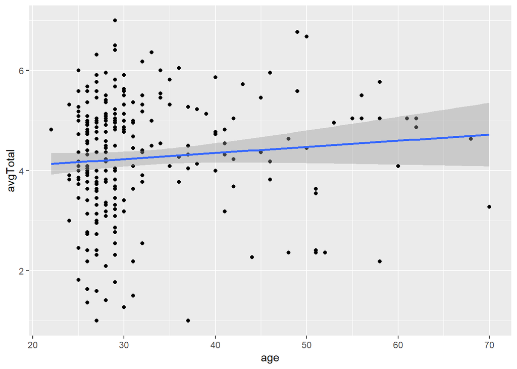

```r
ggplot(clean4, aes(age, avgTotal)) + geom_point() + geom_smooth(method = 'lm', se = TRUE)
```

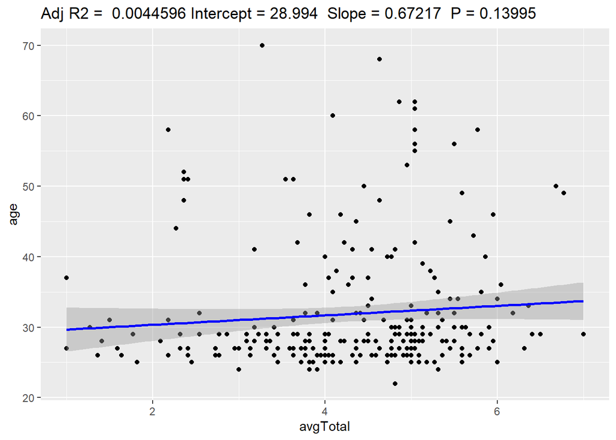

```r
ggplotRegression <- function (fit) {
  require(ggplot2)
  ggplot(fit$model, aes_string(x = names(fit$model)[2], y = names(fit$model)[1])) +
  geom_point() +
  stat_smooth(method = "lm", col = "blue") +
  labs(title = paste("Adj R2 = ",signif(summary(fit)$adj.r.squared, 5),"Intercept =",signif(fit$coef[[1]],5 )," Slope =",signif(fit$coef[[2]], 5), " P =",signif(summary(fit)$coef[2,4], 5)))
}

fit1 <- lm(age ~ avgTotal, data = clean4)
ggplotRegression(fit1)
```

```r
#No relationship between total average and age

wilcox.test(data = clean4, avgTotal ~ gender)
```

```
##
##  Wilcoxon rank sum test with continuity correction
##
## data:  avgTotal by gender
## W = 9132, p-value = 0.2033
## alternative hypothesis: true location shift is not equal to 0
```

```r
t.test(data = clean4, avgTotal ~ gender)
```

```
##
##  Welch Two Sample t-test
##
## data:  avgTotal by gender
## t = -0.71334, df = 280.98, p-value = 0.4762
## alternative hypothesis: true difference in means is not equal to 0
## 95 percent confidence interval:
##  -0.3784403  0.1771150
## sample estimates:
##   mean in group male mean in group female
##             4.219097             4.319760
```

```r
#No relationship between total average and gender
wilcox.test(data = clean4, avgTotal ~ position2)
```

```
##
##  Wilcoxon rank sum test with continuity correction
##
## data:  avgTotal by position2
## W = 5652, p-value = 0.01092
## alternative hypothesis: true location shift is not equal to 0
```

```r
t.test(data = clean4, avgTotal ~ position2)
```

```
##
##  Welch Two Sample t-test
##
## data:  avgTotal by position2
## t = -2.4502, df = 106.14, p-value = 0.01591
## alternative hypothesis: true difference in means is not equal to 0
## 95 percent confidence interval:
##  -0.74093694 -0.07816315
## sample estimates:
##  mean in group resident mean in group dept head
##                4.171717                4.581267
```

```r
#Small significant difference between total average and being a resident or department head

kruskal.test(clean4$avgTotal, clean4$department) #did both kruskal wallis and one-way anova because wasn't sure which was more appropriate
```

```
##
##  Kruskal-Wallis rank sum test
##
## data:  clean4$avgTotal and clean4$department
## Kruskal-Wallis chi-squared = 12.452, df = 8, p-value = 0.1321
```

```r
summary(aov(clean4$avgTotal~clean4$department))
```

```
##                    Df Sum Sq Mean Sq F value Pr(>F)
## clean4$department   8   20.1   2.513    1.82 0.0733 .
## Residuals         271  374.2   1.381
## ---
## Signif. codes:  0 '***' 0.001 '**' 0.01 '*' 0.05 '.' 0.1 ' ' 1
## 25 observations deleted due to missingness
```

```r
#No relationship between total average and department

byDepartment <- group_by(clean4, department)
byDepartment <- summarise(byDepartment, count = n(),avgByDepartment = mean(avgTotal, na.rm = TRUE))
byDepartment
```

```
## # A tibble: 10 x 3
##    department        count avgByDepartment
##    <fct>             <int>           <dbl>
##  1 anesthesia           33            4.43
##  2 general surgery      34            4.52
##  3 internal medicine    64            4.31
##  4 obgyn                60            3.85
##  5 other                 9            4.89
##  6 pathology            15            4.59
##  7 pediatrics           40            4.14
##  8 radiology            17            4.52
##  9 trauma               30            4.12
## 10 <NA>                  3            5.17
```

## Bar Graph

```r
pt2Vis <- transmute(clean4,
                    avgResearchDesign,
                    avgResearchManagement,
                    avgCollaborative,
                    avgImplementation,
                    avgResults,
                    avgTotal)

class(pt2Vis)
```

```
## [1] "data.frame"
```

```r
#pt2Vis <- t(pt2Vis)
pt2Vis <- as.data.frame(pt2Vis)

pt3Vis <- transmute(pt2Vis, design = (mean(pt2Vis[,1], na.rm=TRUE)), management = (mean(pt2Vis$avgResearchManagement, na.rm=TRUE)), collaborate = (mean(pt2Vis$avgCollaborative, na.rm=TRUE)), implement = (mean(pt2Vis$avgImplementation, na.rm=TRUE)), results = (mean(pt2Vis$avgResults, na.rm=TRUE)), total = (mean(pt2Vis$avgTotal, na.rm=TRUE)))

design <- (mean(pt2Vis[,1], na.rm=TRUE))
management <- (mean(pt2Vis$avgResearchManagement, na.rm=TRUE))
collaborate <- (mean(pt2Vis$avgCollaborative, na.rm=TRUE))
implement <- (mean(pt2Vis$avgImplementation, na.rm=TRUE))
results <- (mean(pt2Vis$avgResults, na.rm=TRUE))
total <- (mean(pt2Vis$avgTotal, na.rm=TRUE))
pt3Vis <- data.frame(design, management, collaborate, implement, results, total)
pt3Vis <- t(pt3Vis)
pt3Vis <- round(pt3Vis[,1], digits=2)
pt3Vis <- data.frame(pt3Vis)
class(pt3Vis)
```

```
## [1] "data.frame"
```

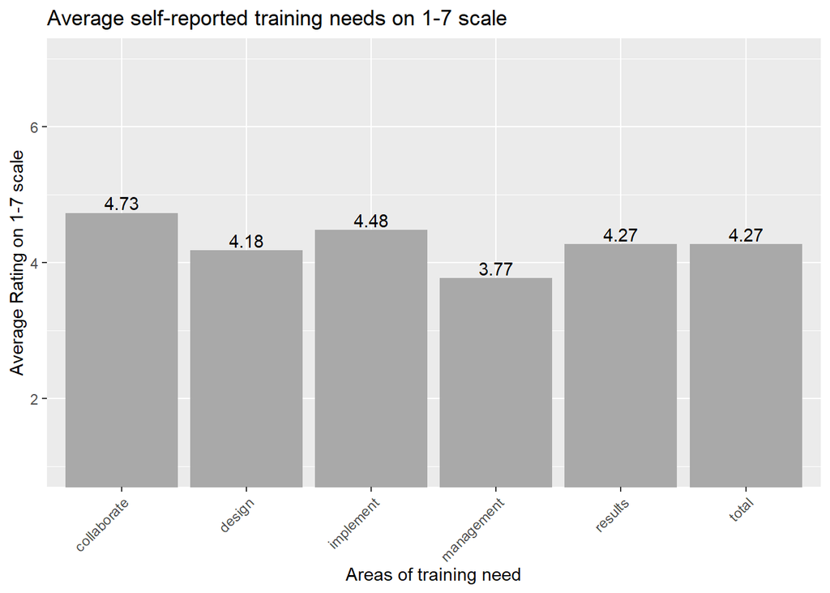

```r
pt3Vis <- pt3Vis %>% mutate(c("design", "management", "collaborate", "implement", "results", "total"))
names(pt3Vis) <- c("item_average", "name")

###########################################################################################################################

ggplot(data = pt3Vis, aes(x = name, y = item_average, fill = item_average)) +
  geom_bar(stat = "identity", fill="darkgray") +
  geom_text(aes(label=item_average), position=position_dodge(width=0.9), vjust=-0.25) +
  theme(axis.text.x = element_text(angle = 45, hjust = 1), legend.position = "none") +
  scale_y_continuous("Average Rating on 1-7 scale") +
  xlab("Areas of training need") +
  #scale_x_continuous("Elements of Systematic Capacity Building") +
  ggtitle("Average self-reported training needs on 1-7 scale") +
  coord_cartesian(ylim=c(1,7))
```

```r
###########################################################################################################################
```